# Lukasz Grad Homework 5 - Feature Importance for COMPAS

We focus on modelling recidivism and violent recidivism as binary classification. Specifically, the positive class denotes whether an individual will commit a crime (a violent crime) within a 2-year period.

```r
vip_xgb <- variable_importance(xgb_explain, loss_function = DALEX::loss_one_minus_auc)
vip_rf <- variable_importance(rf_explain, loss_function = DALEX::loss_one_minus_auc)
vip_glmnet <- variable_importance(cv_glmnet_explain, loss_function = DALEX::loss_one_minus_auc)
```

```r
vip_xgb_violent <- variable_importance(xgb_explain_violent, loss_function = DALEX::loss_one_minus_auc)
vip_rf_violent <- variable_importance(rf_explain_violent, loss_function = DALEX::loss_one_minus_auc)
vip_glmnet_violent <- variable_importance(cv_glmnet_explain_violent, loss_function = DALEX::loss_one_minus_auc)
```

## 2. Calculate permutational variable importance for the selected model

Tuned XGBoost model for recidivism

We can see that the most important variable is the number of previous arrests. Another important factor is the age of a person - younger people are much more likely to commit crime again. Third indicator is the number of previous misdemeanors. It may be that people commiting lesser crimes are more likely to do it again. Final important factor is the age of first offense. People with a crime history beginning at teen age are more likely to reoffend in future.

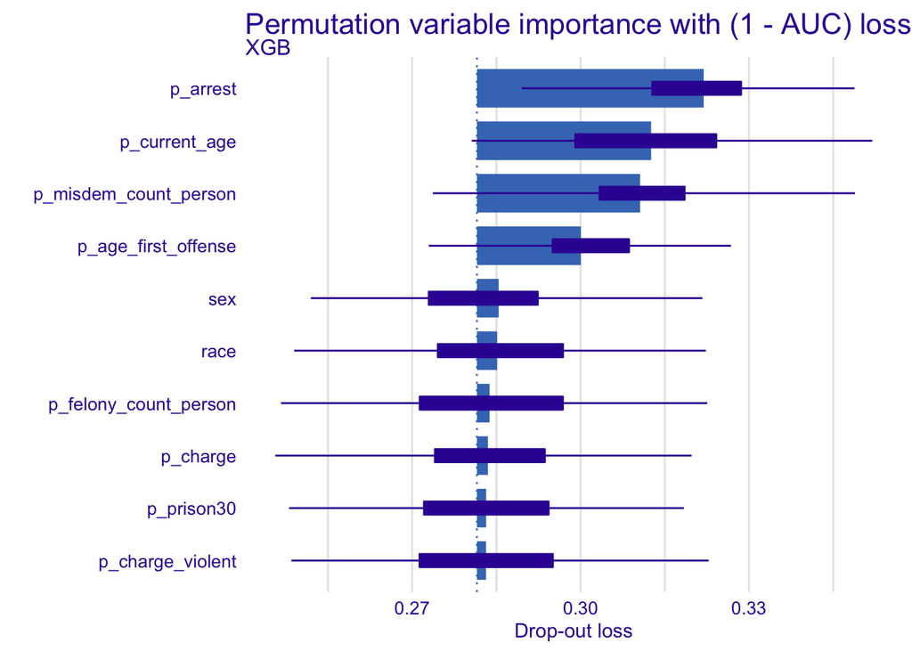

```r
plot(vip_xgb, max_vars = 10) +
    ggtitle('Permutation variable importance with (1 - AUC) loss')
```

Tuned XGBoost model for violent recidivism

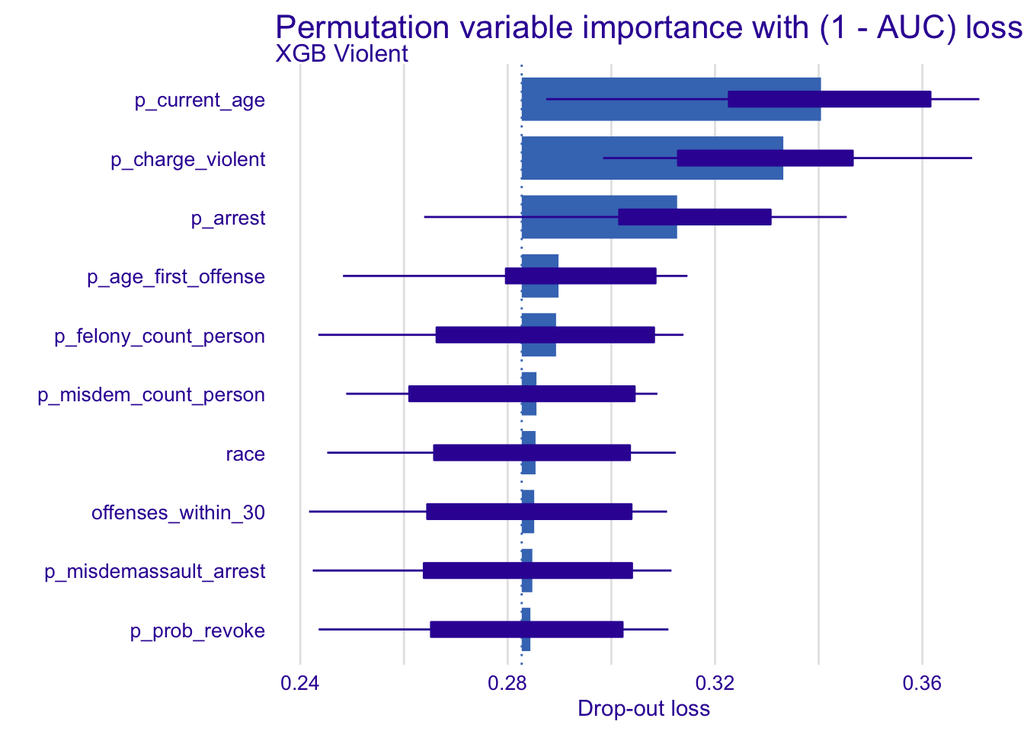

```r
plot(vip_xgb_violent, max_vars = 10) +
    ggtitle('Permutation variable importance with (1 - AUC) loss')
```

## 3. Train three or more candidate models (different variables, different transformations, different model structures) and compare ranking of important features between these models. Are they similar or different?

Here we show the analysis only for basic recidivism problem.

As for the tree models - we see similar variables chosen as important. RF model also treats number of probations as a significant factor.

In case of the Logistic Lasso, we see that basically only age of first offense and number of misdemeanor variables are significant. This strongly suggests presence of highly correlated variables, which indeed is the case. Age and age of first offense are highly correlated, similarily, number of misdemeanors and number of arrests are also highly dependent.

In XGB and LL models, sex and race factors are mildly significant. In RF sex and race are not selected as important.

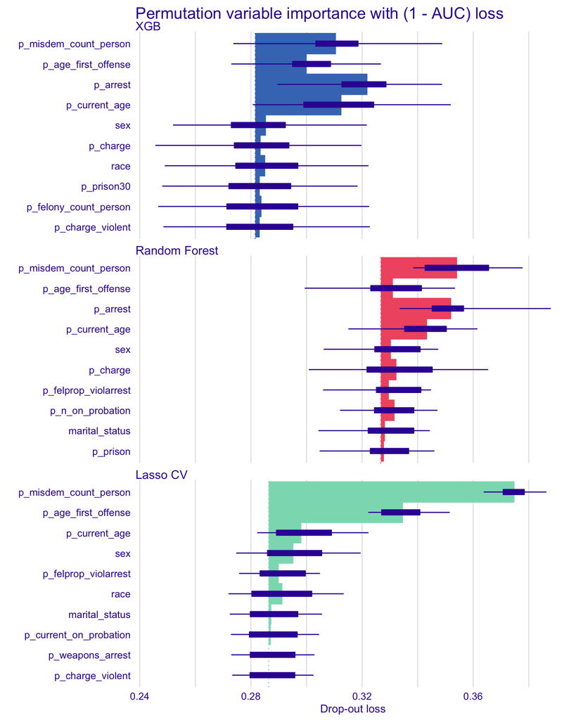

```r
plot(vip_xgb, vip_rf, vip_glmnet, max_vars = 10) +
    ggtitle('Permutation variable importance with (1 - AUC) loss')
```

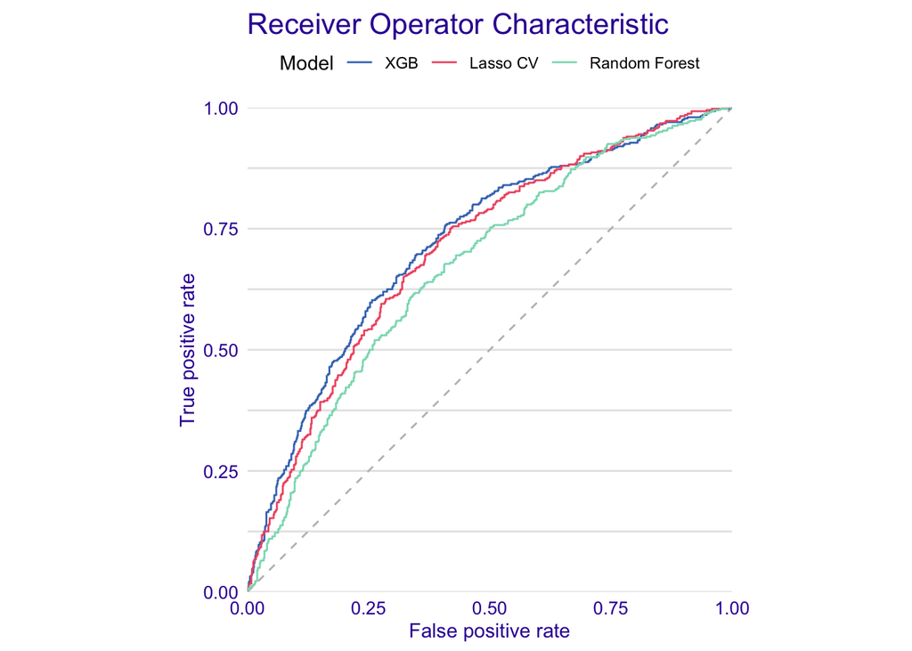

```r
plot(xgb_perf, glmnet_perf, rf_perf, geom = "roc")
```

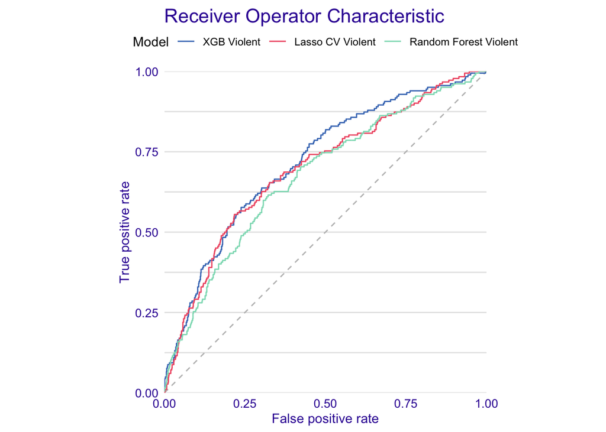

```r
plot(xgb_perf_violent, glmnet_perf_violent, rf_perf_violent, geom = "roc")
```